# Predict the Departure Delay

#### Phase A - Data Preparation

1. Read the dataset and do minor pre-processing
2. Dummy encode categorical variables
3. Feature Scaling and Transformation
   - Log Transformation
   - Min-Max scaling on DepDelay
   - Sqrt Transformation
4. Normalize Data
5. Outlier Detection and treatment
6. Train-Test split data and separate by airline

#### Phase B - Linear Regression and Assumptions

1. Run OLS regression
2. Test for assumptions of linearity

#### Phase C - Model Building

1. Are weather factors important in predicting flight delays? Which factors are most important?
   - Use recursive feature elimination to find best features for each model:
     - Desicion Trees
     - AdaBoost
     - Gradiant Boost
     - Random FOrest
   - Plot partial dependency plots
   - Check the effect of using PCA
2. Are airlines F9 and MQ more affected by weather than other airlines?
   - How does the R2 and RMSE change by adding weather features?
     - On the entire flights data for all airlines
     - On the specific airline data
     - On all other airline data
3. How important is competition in predicting delays?
   - How does the R2 and RMSE change by adding competition features?
     - On the entire flights data for all airlines
     - On the specific airline data
     - On all other airline data
   - Plot partial dependency plots
4. How important is the average 4 hour delay in predicting delays?
   - How does the R2 and RMSE change by adding the average delay feature?
   - Plot partial dependency plots

## Phase A - Data Preparation

### 1. Read the dataset and do minor pre-processing

```python
import pandas as pd
import numpy as np
import matplotlib.pyplot as plt

import warnings
warnings.filterwarnings('ignore')

dataset = pd.read_csv("cleaned2.1.csv", index_col=0)
dataset_original = dataset.copy()
dataset.head()
```

|  | Month | TaxiOut | DayOfWeek | CancellationCode | CRSDepTime | CRSArrTime | CRSElapsedTime | UniqueCarrier | FlightNum | ArrDelay | ... | SecurityDelay | LateAircraftDelay | Compet_daily | Compet_yearly | Avg_Delay_4hours | TaxiOut_y | DepDelay_y | Month_bins | DepTime_bins | DayOfMonthCategories |
| --- | --- | --- | --- | --- | --- | --- | --- | --- | --- | --- | --- | --- | --- | --- | --- | --- | --- | --- | --- | --- | --- |
| 0 | 1 | 10.0 | 4 | NaN | 17.0 | 20.0 | 105.0 | WN | 230 | 15.0 | ... | 0.0 | 11.0 | 18.484848 | 20.180886 | 10.953488 | 9.677966 | 32.025424 | Winter | Afternoon | 1 |
| 1 | 1 | 9.0 | 4 | NaN | 20.0 | 23.0 | 105.0 | WN | 361 | 32.0 | ... | 0.0 | 21.0 | 18.484848 | 20.180886 | 22.777778 | 9.677966 | 32.025424 | Winter | Evening | 1 |
| 2 | 1 | 5.0 | 4 | NaN | 13.0 | 16.0 | 105.0 | WN | 397 | 11.0 | ... | NaN | NaN | 18.484848 | 20.180886 | 8.921053 | 9.677966 | 32.025424 | Winter | Afternoon | 1 |
| 3 | 1 | 8.0 | 4 | NaN | 9.0 | 12.0 | 105.0 | WN | 3245 | -7.0 | ... | NaN | NaN | 18.484848 | 20.180886 | 3.000000 | 9.677966 | 32.025424 | Winter | Morning | 1 |
| 4 | 1 | 7.0 | 4 | NaN | 10.0 | 15.0 | 170.0 | WN | 304 | -1.0 | ... | NaN | NaN | 18.484848 | 20.180886 | -0.282609 | 9.677966 | 32.025424 | Winter | Morning | 1 |

5 rows × 34 columns

```python
to_remove_reg = ["Dest", 'CRSArrTime', 'FlightNum',"CancellationCode", "ArrDelay"]
dataset = dataset.drop(to_remove_reg, axis =1)
```

```python
to_set_as_nan = ["tmpf","dwpf","sknt","alti","mslp","vsby"]
for s in to_set_as_nan:
    dataset.loc[dataset[s]=="M", s] = np.NaN
dataset.loc[dataset.Avg_Delay_4hours.isna(), "Avg_Delay_4hours"] = 0
```

```python
dataset = dataset[dataset.Cancelled == 0]
dataset = dataset.drop("Cancelled", axis=1)

is_na = ["tmpf","dwpf","alti","sknt","WeatherDelay"]
for s in is_na:
    dataset = dataset[dataset[s].isna() == False]

to_drop = ["mslp", "vsby"]
dataset = dataset.drop(to_drop, axis=1)
dataset.head()
```

|  | Month | TaxiOut | DayOfWeek | CRSDepTime | CRSElapsedTime | UniqueCarrier | DepDelay | Origin | Distance | tmpf | ... | SecurityDelay | LateAircraftDelay | Compet_daily | Compet_yearly | Avg_Delay_4hours | TaxiOut_y | DepDelay_y | Month_bins | DepTime_bins | DayOfMonthCategories |
| --- | --- | --- | --- | --- | --- | --- | --- | --- | --- | --- | --- | --- | --- | --- | --- | --- | --- | --- | --- | --- | --- |
| 0 | 1 | 10.0 | 4 | 17.0 | 105.0 | WN | 25.0 | LAX | 677 | 55.94 | ... | 0.0 | 11.0 | 18.484848 | 20.180886 | 10.953488 | 9.677966 | 32.025424 | Winter | Afternoon | 1 |
| 1 | 1 | 9.0 | 4 | 20.0 | 105.0 | WN | 40.0 | LAX | 677 | 59.00 | ... | 0.0 | 21.0 | 18.484848 | 20.180886 | 22.777778 | 9.677966 | 32.025424 | Winter | Evening | 1 |
| 6 | 1 | 8.0 | 4 | 15.0 | 225.0 | WN | 52.0 | LAX | 1797 | 53.96 | ... | 0.0 | 24.0 | 18.484848 | 20.180886 | 9.121212 | 9.677966 | 32.025424 | Winter | Afternoon | 1 |
| 7 | 1 | 11.0 | 4 | 13.0 | 225.0 | WN | 32.0 | LAX | 1797 | 57.92 | ... | 0.0 | 12.0 | 18.484848 | 20.180886 | 8.921053 | 9.677966 | 32.025424 | Winter | Afternoon | 1 |
| 9 | 1 | 8.0 | 4 | 17.0 | 110.0 | WN | 110.0 | LAX | 714 | 55.94 | ... | 0.0 | 91.0 | 18.484848 | 20.180886 | 10.953488 | 9.677966 | 32.025424 | Winter | Afternoon | 1 |

5 rows × 26 columns

### 2. Dummy encode categorical variables

```python
to_encode = ['CRSDepTime','Month', 'Month_bins','DayOfMonthCategories','Origin','DayOfWeek', 'UniqueCarrier', 'DepTime_bins']
dataset = pd.get_dummies(dataset, prefix_sep="_", columns=to_encode)
```

### 3. Feature Scaling and Transformation

- Log Transformation
- Min-Max scaling on DepDelay
- Sqrt Transformation

```python
numerical = ['TaxiOut', 'CRSElapsedTime', 'DepDelay', 'Distance', 'tmpf', 'dwpf', 'sknt', 'alti',
             'Compet_daily', 'Compet_yearly', 'Avg_Delay_4hours', 'TaxiOut_y', 'DepDelay_y']
```

```python
from sklearn.preprocessing import MinMaxScaler

to_log_trans = ['TaxiOut', 'TaxiOut_y', 'CRSElapsedTime', 'Distance', 'sknt']

dataset[to_log_trans].apply(np.log1p, axis =1)

dataset["DepDelayTrans"] = np.sqrt(MinMaxScaler(feature_range=(0, 1)).fit_transform(dataset[["DepDelay"]]))
dataset["WeatherDelayTrans"] = np.sqrt(MinMaxScaler(feature_range=(0, 1)).fit_transform(dataset[["WeatherDelay"]]))
dataset["dwpfTrans"] = np.log1p(dataset["dwpf"]**2)
```

### 4. Normalize Data

```python
to_normalize = ['CRSElapsedTime','Distance',"TaxiOut",'tmpf',"dwpf",'alti','sknt', 'Compet_daily', 'Compet_yearly', 'TaxiOut_y', 'DepDelay_y',"Avg_Delay_4hours"]
from sklearn.preprocessing import StandardScaler

dataset[['Compet_daily_org', 'Compet_yearly_org']] = dataset[['Compet_daily', 'Compet_yearly']]
scaler = StandardScaler()
dataset[to_normalize] = scaler.fit_transform(dataset[to_normalize].values)
```

### 5. Outlier Detection

```python
df_sample = dataset.copy()
df_sample = df_sample.sample(300000)
```

```python
from sklearn.neighbors import LocalOutlierFactor

loc= LocalOutlierFactor(n_neighbors = 30, contamination = 0.05)
outliers_loc = loc.fit_predict(df_sample)

outliers_loc = pd.DataFrame(outliers_loc, index= df_sample.index.values)
df_sample['outlier'] = outliers_loc
df_sample.groupby(["outlier"]).size()
```

```
outlier
-1     15000
 1    285000
dtype: int64
```

```python
df_sample = df_sample[df_sample.outlier == 1]
df_sample = df_sample.drop("outlier", axis=1)
df_sample.shape
```

```
(285000, 107)
```

### 6. Train-Test split data and separate by airline

The data is split into 3 main parts:

1. Full dataset: this includes all airlines
2. Specific airlines: this includes the airlines of interest F9 and MQ
3. All other airlines: this includes all airlines except the specific airlines in the previous data set

The splits are used to test the effect of certain factors on our airlines as compared to their effect on the entire industry.

```python
from sklearn.model_selection import train_test_split

y = df_sample["DepDelayTrans"]
x = df_sample
X_train, X_test, y_train, y_test = train_test_split(x, y, test_size=0.3)

# data was sampled for OLS to reduce the time to test for the assumptions of linear regression
df_ols = df_sample.sample(5000)
y_ols = df_ols["DepDelayTrans"]
x_ols = df_ols
# X_train_ols, X_test_ols, y_train_ols, y_test_ols = train_test_split(x_ols, y_ols, test_size=0.3)

y = df_sample["DepDelayTrans"]
x = df_sample
X_train, X_test, y_train, y_test = train_test_split(x, y, test_size=0.3)

df_f9_mq = df_sample.loc[(dataset['UniqueCarrier_F9'] == 1) | (dataset['UniqueCarrier_MQ'] == 1)]
y_f9_mq =  df_f9_mq["DepDelayTrans"]
x_f9_mq =  df_f9_mq
X_train_f9_mq, X_test_f9_mq, y_train_f9_mq, y_test_f9_mq = train_test_split(x_f9_mq, y_f9_mq, test_size=0.3)

df_others = df_sample.loc[(dataset['UniqueCarrier_F9'] == 0) | (dataset['UniqueCarrier_MQ'] == 0)]
y_others =  df_others["DepDelayTrans"]
x_others =  df_others
X_train_others, X_test_others, y_train_others, y_test_others = train_test_split(x_others, y_others, test_size=0.3)
```

```python
weather = ["alti","sknt","dwpfTrans","tmpf"]
competition = ['Compet_yearly', 'Compet_daily']
delays = ["TaxiOut","Avg_Delay_4hours"]
originCols = [i for i in x.columns if "Origin" in i ]
dayofweekCols = [i for i in x.columns if "DayOfWeek" in i ]
monthbinsCols = [i for i in x.columns if "Month_bins" in i]
depTimeBinsCols = [i for i in x.columns if "DepTime_bins" in i]
airlines = [i for i in x.columns if "UniqueCarrier" in i]
```

## Phase B - Linear Regression and Assumptions

### 1. Run OLS regression

```python
import statsmodels.api as sm
from statsmodels.sandbox.regression.predstd import wls_prediction_std

from sklearn.preprocessing import PolynomialFeatures

X_constant = sm.add_constant(x_ols[weather+competition+delays+originCols+dayofweekCols+monthbinsCols+depTimeBinsCols])
lin_reg = sm.OLS(y_ols, X_constant).fit()

print("Regular OLS")
print(f"R-Squared {lin_reg.rsquared:.5} | Adjusted R-Squared {lin_reg.rsquared_adj:.5} | F-Statistic: {lin_reg.fvalue:.5} | F P-value: {lin_reg.f_pvalue}")

degree = 2
poly_feats = PolynomialFeatures(degree=degree)
xp = poly_feats.fit_transform(X_constant)

lin_reg_poly = sm.OLS(y_ols, xp).fit()

print("\nPolynomial fitted OLS (degree={degree})")
print(f"R-Squared {lin_reg_poly.rsquared:.5} | Adjusted R-Squared {lin_reg_poly.rsquared_adj:.5} | F-Statistic: {lin_reg_poly.fvalue:.5} | F P-value: {lin_reg_poly.f_pvalue}")
```

```
Regular OLS
R-Squared 0.13187 | Adjusted R-Squared 0.1268 | F-Statistic: 26.032 | F P-value: 1.035491886626314e-129

Polynomial fitted OLS (degree={degree})
R-Squared 0.22455 | Adjusted R-Squared 0.16021 | F-Statistic: 3.4899 | F P-value: 3.7600867173678834e-88
```

#### Primary thoughts on the observed model

The linear regression model shows a significant value for the R-squared statistic and the model's p-value is significant to reject the null hypothesis indicating that the coefficients are not all equal to zero.

On the other hand, adding polynomial interactions significantly increased the R-squared metric but the adjusted R-squared shows little improvement. Also, the log-likelihood shows a small increase as well. This indicates that we may be overfitting.

To verify the model we will run some tests on the assumptions of a linear regression model.

### 2. Test for assumptions of linearity

#### Linearity and Homoscedasticity

```python
%matplotlib inline
import seaborn as sns
import matplotlib.pyplot as plt
import statsmodels.stats.api as sms
import scipy.stats as stats
sns.set_style('darkgrid')
sns.mpl.rcParams['figure.figsize'] = (15.0, 2.5)
```

```
Regular OLS
```

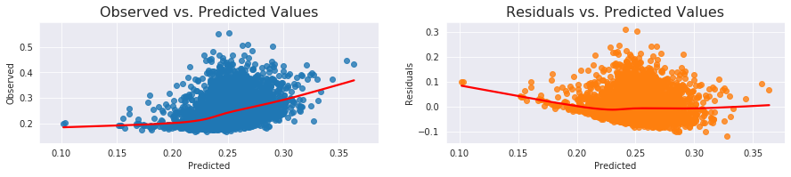

```
Polynomial fitted OLS
```

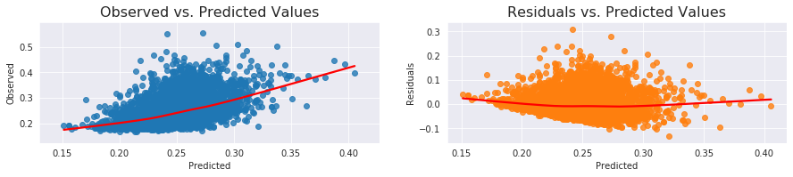

```python
def linearity_test(model, y):
    fitted_vals = model.predict()
    resids = model.resid

    fig, ax = plt.subplots(1,2)

    sns.regplot(x=fitted_vals, y=y, lowess=True, ax=ax[0], line_kws={'color': 'red'})
    ax[0].set_title('Observed vs. Predicted Values', fontsize=16)
    ax[0].set(xlabel='Predicted', ylabel='Observed')

    sns.regplot(x=fitted_vals, y=resids, lowess=True, ax=ax[1], line_kws={'color': 'red'})
    ax[1].set_title('Residuals vs. Predicted Values', fontsize=16)
    ax[1].set(xlabel='Predicted', ylabel='Residuals')
    plt.show()


print('Regular OLS')
linearity_test(lin_reg, y_ols)
print('Polynomial fitted OLS')
linearity_test(lin_reg_poly, y_ols)
```

- The above regression plots show that the dots are not randomly scattered around the regression line which in turn does not look perfectly linear with a sligh tendancy to a parabolic line.
- Therfore the first assumption of linearity is violated

```
Regular OLS
 Breusch-Pagan test ----
                                   value
Lagrange multiplier statistic  74.593646
p-value                         0.000047
f-value                         2.595483
f p-value                       0.000006

 Goldfeld-Quandt test ----
                value
F statistic  0.979657
p-value      0.695211

 Residuals plots ----
```

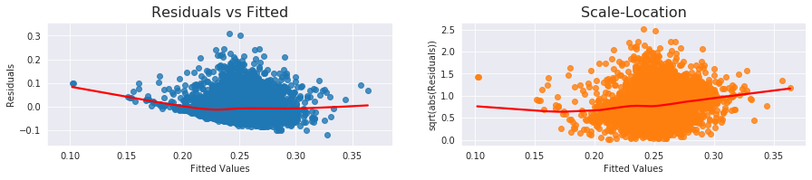

```
Polynomial fitted OLS
 Breusch-Pagan test ----
                                    value
Lagrange multiplier statistic  384.512784
p-value                          1.000000
f-value                          1.004061
f p-value                        0.470049

 Goldfeld-Quandt test ----
                value
F statistic  0.977749
p-value      0.697615

 Residuals plots ----
```

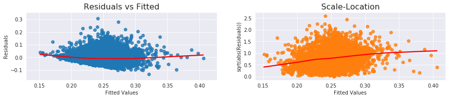

```python
def homoscedasticity_test(model):
    fitted_vals = model.predict()
    resids = model.resid
    resids_standardized = model.get_influence().resid_studentized_internal

    fig, ax = plt.subplots(1,2)

    sns.regplot(x=fitted_vals, y=resids, lowess=True, ax=ax[0], line_kws={'color': 'red'})
    ax[0].set_title('Residuals vs Fitted', fontsize=16)
    ax[0].set(xlabel='Fitted Values', ylabel='Residuals')

    sns.regplot(x=fitted_vals, y=np.sqrt(np.abs(resids_standardized)), lowess=True, ax=ax[1], line_kws={'color': 'red'})
    ax[1].set_title('Scale-Location', fontsize=16)
    ax[1].set(xlabel='Fitted Values', ylabel='sqrt(abs(Residuals))')

    bp_test = pd.DataFrame(sms.het_breuschpagan(resids, model.model.exog),
                           columns=['value'],
                           index=['Lagrange multiplier statistic', 'p-value', 'f-value', 'f p-value'])

    gq_test = pd.DataFrame(sms.het_goldfeldquandt(resids, model.model.exog)[:-1],
                           columns=['value'],
                           index=['F statistic', 'p-value'])

    print(' Breusch-Pagan test ----')
    print(bp_test)
    print('\n Goldfeld-Quandt test ----')
    print(gq_test)
    print('\n Residuals plots ----')
    plt.show()

print('Regular OLS')
homoscedasticity_test(lin_reg)
print('Polynomial fitted OLS')
homoscedasticity_test(lin_reg_poly)
```

#### Normality

```
-----regular fitted regression
Jarque-Bera test ---- statistic: 2731.2326, p-value: 0.0
Shapiro-Wilk test ---- statistic: 0.9098, p-value: 0.0000
Kolmogorov-Smirnov test ---- statistic: 0.4643, p-value: 0.0000
```

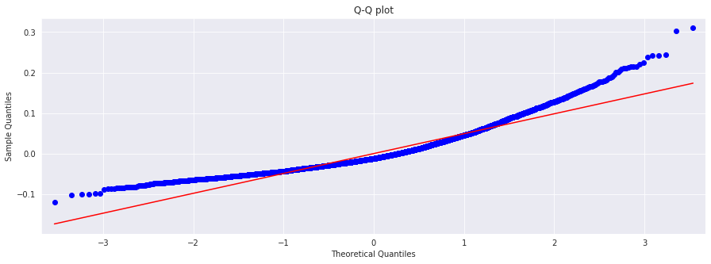

```
-----Polynomial fitted regression
Jarque-Bera test ---- statistic: 2551.9587, p-value: 0.0
Shapiro-Wilk test ---- statistic: 0.9232, p-value: 0.0000
Kolmogorov-Smirnov test ---- statistic: 0.4630, p-value: 0.0000
```

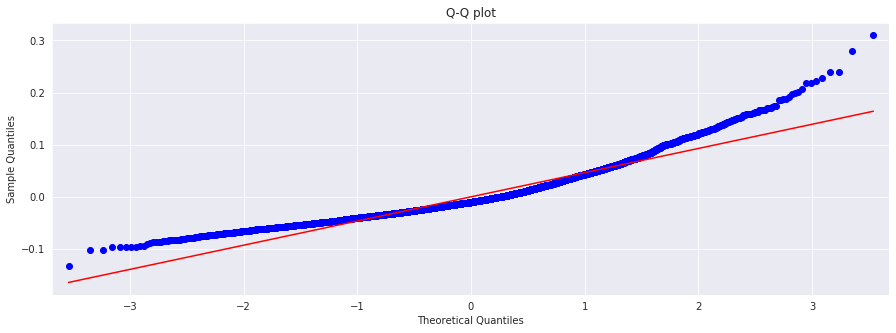

```python
from scipy import stats
sns.mpl.rcParams['figure.figsize'] = (15.0, 5.0)
def normality_of_residuals_test(model):
    sm.ProbPlot(model.resid).qqplot(line='s');
    plt.title('Q-Q plot');

    jb = stats.jarque_bera(model.resid)
    sw = stats.shapiro(model.resid)
    ad = stats.anderson(model.resid, dist='norm')
    ks = stats.kstest(model.resid, 'norm')

    print(f'Jarque-Bera test ---- statistic: {jb[0]:.4f}, p-value: {jb[1]}')
    print(f'Shapiro-Wilk test ---- statistic: {sw[0]:.4f}, p-value: {sw[1]:.4f}')
    print(f'Kolmogorov-Smirnov test ---- statistic: {ks.statistic:.4f}, p-value: {ks.pvalue:.4f}')
    plt.show()

print("-----regular fitted regression")
normality_of_residuals_test(lin_reg)

print("-----Polynomial fitted regression")
normality_of_residuals_test(lin_reg_poly)
```

- The performed tests including Jarque-Bera test, Shapiro-Wilk test and Kolmogorov-Smirnov test all test for the null hypothesis being normally distributed. However the p-values at a critical level of 0.05 indicate that the null hypothesis should be rejected.
- The QQ plots also emphasize on the non normality of the dataset.
- Therfore the assumption of normality is violated.

## Phase C - Model Building

### 1. Are weather factors important in predicting flight delays? Which factors are most important?

##### RFE Approach - Decision Tree, Random Forest, Gradient Boost and AdaBoost Regressors

```python
from sklearn.feature_selection import RFE
from sklearn.metrics import r2_score

from sklearn.metrics import mean_squared_error
from math import sqrt

from sklearn.ensemble import GradientBoostingRegressor
from sklearn.ensemble import RandomForestRegressor
from sklearn.ensemble import AdaBoostRegressor
from sklearn.tree import DecisionTreeRegressor
```

```python
# print top n features
def print_features_with_rank(features, importances):
    zipped_and_sorted = sorted(zip(features, importances),reverse = True, key=lambda x: x[1])
    str = ''
    for x in zipped_and_sorted:
        str += (f"|{x[0]}: {x[1]:.5}")
    print(str+ "|")

def get_top_features(features, importances):
    zipped_and_sorted = sorted(zip(features, importances), key=lambda x: x[1])
    result = [x[0] for x in zipped_and_sorted if x[1] == 1]
    return result

def run_rfe_and_score_best_feature(model, x_train, y_train, x_test, y_test):
    print('--------------------------------------------------------------')
    print(f"\033[1m {type(model).__name__} \033[0m: ", end = '')
    selector = RFE(model, 10, step=1)
    selector = selector.fit(x_train,y_train)

    features = get_top_features(x_train, selector.ranking_)
    model.fit(x_train[features],y_train)

    preds=model.predict(x_test[features])
    print(f"\033[1m R squared:\033[0m {r2_score(y_test,preds):.5} | \033[1m RMSE: \033[0m{sqrt(mean_squared_error(y_test, preds)):.5}",)
    print_features_with_rank(features, model.feature_importances_)
```

```python
from sklearn.model_selection import cross_validate
from sklearn.metrics import mean_squared_error as mse
from math import sqrt


from statistics import mean

def run_cross_validation(model, X, y, nFold):
    print('--------------------------------------------------------------')
    print(f"\033[1m {type(model).__name__} :\033[1m", end='')
    scores = cross_validate(model, X, y, cv=nFold, scoring=('r2', 'neg_mean_squared_error'),
                            return_train_score=True)
    print(f"\033[1m R2: \033[0m {mean(scores['test_r2']):.5} | \033[1m RMSE: \033[0m {sqrt(-mean(scores['test_neg_mean_squared_error'])):.5}")
```

```python
gradBoost_regr = GradientBoostingRegressor(random_state=0, n_estimators=100)
ada_regr = AdaBoostRegressor(random_state=0, n_estimators=200)
# current parameters where set to reduce runtime and space omplexities
# grid search wld be used later if it were found to be performing good
rf = RandomForestRegressor(random_state=0, n_estimators=200, max_features = "auto", min_samples_split=30, min_samples_leaf = 10, max_depth=4)
dt = DecisionTreeRegressor()

models = [rf, gradBoost_regr, ada_regr, dt]
```

```python
print("------------All features------------")
feature_under_test = weather+competition+delays+airlines+originCols+dayofweekCols+monthbinsCols+depTimeBinsCols
for m in models:
    run_rfe_and_score_best_feature(m, X_train[feature_under_test], y_train, X_test[feature_under_test], y_test)

print("\n------------without airlines features------------")
feature_under_test = weather+competition+delays+originCols+dayofweekCols+monthbinsCols+depTimeBinsCols
for m in models:
    run_rfe_and_score_best_feature(m, X_train[feature_under_test], y_train, X_test[feature_under_test], y_test)
```

```
------------All features------------
--------------------------------------------------------------
 RandomForestRegressor :  R squared: 0.14449 |  RMSE: 0.048883
|Avg_Delay_4hours: 0.58128|TaxiOut: 0.38436|UniqueCarrier_UA: 0.023075|Compet_daily: 0.0035003|Origin_ORD: 0.0033218|UniqueCarrier_CO: 0.0023219|Compet_yearly: 0.0014493|UniqueCarrier_US: 0.00026872|UniqueCarrier_B6: 0.00022596|tmpf: 0.0001951|
--------------------------------------------------------------
 GradientBoostingRegressor :  R squared: 0.18099 |  RMSE: 0.047828
|Avg_Delay_4hours: 0.49712|TaxiOut: 0.32087|UniqueCarrier_UA: 0.029029|Compet_daily: 0.028929|Compet_yearly: 0.026453|Origin_LGA: 0.024344|UniqueCarrier_YV: 0.019953|UniqueCarrier_F9: 0.019562|dwpfTrans: 0.016871|Origin_ORD: 0.016865|
--------------------------------------------------------------
 AdaBoostRegressor :  R squared: -0.16995 |  RMSE: 0.057164
|Avg_Delay_4hours: 0.33874|TaxiOut: 0.20523|Compet_daily: 0.14432|UniqueCarrier_NW: 0.098484|Compet_yearly: 0.094949|dwpfTrans: 0.041514|DayOfWeek_5: 0.025591|UniqueCarrier_9E: 0.022878|DayOfWeek_6: 0.015763|tmpf: 0.012528|
--------------------------------------------------------------
 DecisionTreeRegressor :  R squared: -0.61197 |  RMSE: 0.0671
|Avg_Delay_4hours: 0.20629|TaxiOut: 0.17425|Compet_daily: 0.14039|alti: 0.11435|tmpf: 0.096534|dwpfTrans: 0.093255|sknt: 0.076219|Compet_yearly: 0.073432|DepTime_bins_Afternoon: 0.013419|DayOfWeek_7: 0.011864|

------------without airlines features------------
--------------------------------------------------------------
 RandomForestRegressor :  R squared: 0.14198 |  RMSE: 0.048954
|Avg_Delay_4hours: 0.60031|TaxiOut: 0.39033|Compet_daily: 0.0036576|Origin_ORD: 0.0034706|Compet_yearly: 0.0018629|tmpf: 0.00020961|Origin_DFW: 9.2171e-05|Origin_LGA: 3.1615e-05|DepTime_bins_Afternoon: 2.9593e-05|Month_bins_Winter: 0.0|
--------------------------------------------------------------
 GradientBoostingRegressor :  R squared: 0.17984 |  RMSE: 0.047862
|Avg_Delay_4hours: 0.48724|TaxiOut: 0.32342|Compet_yearly: 0.065583|Compet_daily: 0.034944|Origin_ORD: 0.027557|Origin_LGA: 0.022774|dwpfTrans: 0.010994|tmpf: 0.010885|DepTime_bins_Afternoon: 0.010103|DepTime_bins_Morning: 0.0064964|
--------------------------------------------------------------
 AdaBoostRegressor :  R squared: -0.26458 |  RMSE: 0.059431
|Avg_Delay_4hours: 0.36109|Compet_yearly: 0.19895|TaxiOut: 0.19279|Compet_daily: 0.13577|dwpfTrans: 0.048238|DayOfWeek_6: 0.030636|Origin_DCA: 0.013481|alti: 0.0080264|Month_bins_Spring: 0.0077161|DepTime_bins_Evening: 0.0032986|
--------------------------------------------------------------
 DecisionTreeRegressor :  R squared: -0.61941 |  RMSE: 0.067254
|Avg_Delay_4hours: 0.20558|TaxiOut: 0.17427|Compet_daily: 0.14087|alti: 0.1143|tmpf: 0.096729|dwpfTrans: 0.092835|sknt: 0.076769|Compet_yearly: 0.073034|DepTime_bins_Afternoon: 0.013739|DayOfWeek_7: 0.011873|
```

- The results show that only Random Forest and Gradient Boost Regressors have a significant R-squared value above 0.10 and an RMSE of less that 0.05. Therefore we will only consider the results from their output to select the relevant features.
- The weather features that appear in the results are:
  - "dwpfTrans",
  - "tmpf",
- It is good to note that weather features have significantly less importance measure than other features, nevertheless, they seem to be contributing effectively to the models' performance.
- The appearance of some unique carrier dummy variables motivates the comparison of the models on our airlines specifically and then on all other airlines.
- To achieve this, the data is split into two parts, one being data from our specific airlines and another for all other airlines. RFE is run again on the separate data sets.

**Note**: Decision Tree and AdaBoost regressors show a very low R-squared value and therefore will be dropped from further analysis.

```python
models.remove(dt)
models.remove(ada_regr)
```

```python
print("\n------------------------F9 and MQ only------------------------")
feature_under_test = weather+competition+delays+originCols+dayofweekCols+monthbinsCols+depTimeBinsCols
for m in models:
    run_rfe_and_score_best_feature(m, X_train_f9_mq[feature_under_test], y_train_f9_mq, X_test_f9_mq, y_test_f9_mq)
```

```
------------------------F9 and MQ only------------------------
--------------------------------------------------------------
 RandomForestRegressor :  R squared: 0.17797 |  RMSE: 0.03993
|Avg_Delay_4hours: 0.54926|TaxiOut: 0.32485|Origin_DEN: 0.10506|tmpf: 0.015|dwpfTrans: 0.0021897|Compet_daily: 0.0016798|alti: 0.00069005|DayOfWeek_4: 0.00059103|sknt: 0.00036498|Origin_BOS: 0.00031013|
--------------------------------------------------------------
 GradientBoostingRegressor :  R squared: 0.20773 |  RMSE: 0.039201
|Avg_Delay_4hours: 0.47102|TaxiOut: 0.28342|Origin_DEN: 0.099965|Compet_daily: 0.039996|tmpf: 0.036406|Compet_yearly: 0.018979|dwpfTrans: 0.016065|DepTime_bins_Evening: 0.012532|Origin_LGA: 0.012397|alti: 0.0092185|
```

```python
print("\n------------All Other Airlines------------\n")
feature_under_test = weather+competition+delays+originCols+dayofweekCols+monthbinsCols+depTimeBinsCols
for m in models:
    run_rfe_and_score_best_feature(m, X_train_others[feature_under_test], y_train_others, X_test_others, y_test_others)
```

```
------------All Other Airlines------------

--------------------------------------------------------------
 RandomForestRegressor :  R squared: 0.14051 |  RMSE: 0.049342
|Avg_Delay_4hours: 0.59279|TaxiOut: 0.3946|Compet_yearly: 0.0044349|Compet_daily: 0.003789|Origin_ORD: 0.0029143|Origin_DFW: 0.00059689|tmpf: 0.00045402|DepTime_bins_Morning: 0.00032992|alti: 5.7851e-05|Origin_DEN: 3.5779e-05|
--------------------------------------------------------------
 GradientBoostingRegressor :  R squared: 0.17849 |  RMSE: 0.048239
|Avg_Delay_4hours: 0.4805|TaxiOut: 0.32958|Compet_yearly: 0.073828|Compet_daily: 0.029008|Origin_ORD: 0.027435|Origin_LGA: 0.023448|dwpfTrans: 0.010723|tmpf: 0.010706|DepTime_bins_Morning: 0.0074329|DepTime_bins_Afternoon: 0.0073311|
```

- The results show that after removing the airline feature and splitting the data set, for our specific airline, we notice the presence of new weather feature "alti" under the gradient boost model which is the best performing. However results for all other airlines show the same weather features as before the split.
- For further verification on the inmportant weather features, the partial dependency plots are drawn under the gradient boost model.

##### Partial dependence plots of weather features under Gradient Boost model

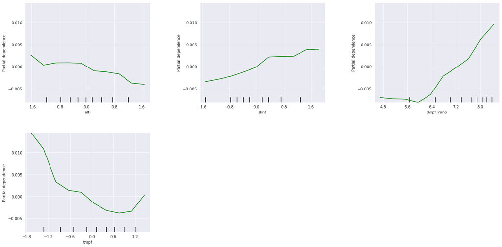

```python
from sklearn.ensemble.partial_dependence import partial_dependence, plot_partial_dependence

import seaborn as sns

sns.mpl.rcParams['figure.figsize'] = (20.0, 15.0)

gradBoost_regr.fit(x[weather],y)
my_plots = plot_partial_dependence(gradBoost_regr,
                                   features=range(0, len(weather)), # column numbers of plots we want to show
                                   X=x[weather],            # raw predictors data.
                                   feature_names=weather, # labels on graphs
                                   grid_resolution=10) # number of values to plot on x axis
```

- The partial dependency plots show that the greatest dependency of departure delay is on "tmpf" and "dwpfTrans", which is consistant with the results of the RFE approach.
- "sknt" and "alti" plots show a rather straight line with a relatively small slope. This does not indicate a strong dependency of DepDelay.
- Therefore we will select the features based on the follwoing reasoning:
  - "alti", "dwpfTrans", "tmpf": selected features for our specific airlines dataset under RFE and the partial dependency plot shows a relation to the dependent variable with a non zero slope.
  - "Compet_daily", "Taxiout", "Avg_Delay_4hours": Appears in all RFE results of all datasets and models with a substantial importance rank.
  - "Origin_DEN", "Origin_LGA": Appear as selected features for our airlines under the RFE approach for Gradient boost model which is giving the highest R-squared value.
  - "DepTime_bins_Evening": Appears as a selected feature under RFE results for our airlines dataset.

```python
selected_features = ["alti","dwpfTrans","tmpf","Compet_daily","TaxiOut","Avg_Delay_4hours","Origin_DEN",
                    "Origin_LGA","DepTime_bins_Evening"]
```

#### Remarks

Some weather features seem to be of high importance as expected. Under all models, they where selected substantial features. From the partial dependency plots we notice that the strongest relationship with departure delay is given by the "tmpf" variable or air temperature at 2 meters above ground level. Given a negative slope we can conclude that as temperatures drop a delay is more probable. A drop in temperature usually indicates winter weather which could mean heavy rain and un-wanted weather complications to flights. On the other hand, "dwpfTransf" or dew point, indicates that the air is relatively humid and is an indication of rain and a stormy weather and thus further supporting the evidence expressed by the tempearture.

### Check the effect of using PCA

```
------------with airlines features------------
```

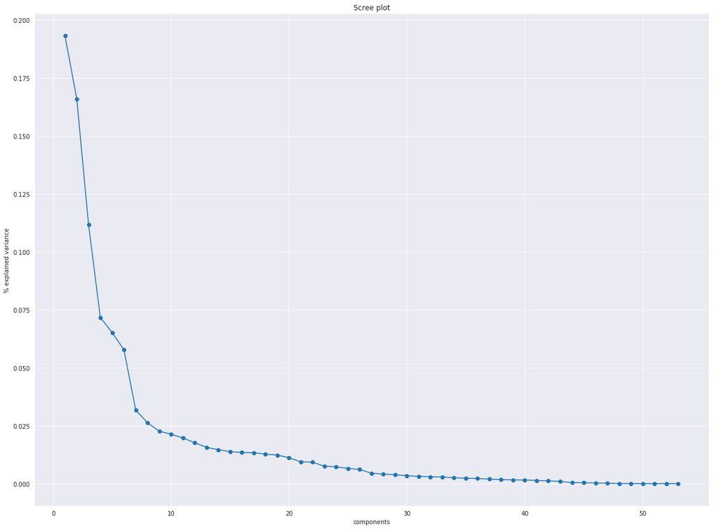

```
PCA(copy=True, iterated_power='auto', n_components=None, random_state=None,
    svd_solver='auto', tol=0.0, whiten=False)
```

```python
from sklearn.decomposition import PCA
from sklearn.preprocessing import normalize
from pandas.plotting import scatter_matrix
import matplotlib.cm as cm
from random import randint

def find_relevant_variable(component, threshold, data):
    variables = []
    weights = []

    for i, var in zip(range(0,len(data.keys())), data.keys()):
        if abs(component[i])>threshold:
            variables.append(var)
            weights.append(component[i])

    return variables, weights


def run_pca(pca_data, n, plot=True):
    X_pca = normalize(pca_data)

    if n == None:
        pca = PCA()
    else:
        pca = PCA(n_components=n)

    pca.fit(X_pca)

    if plot:
        plt.plot(range(1,len(pca.components_)+1),pca.explained_variance_ratio_,'-o')
        plt.xlabel('components')
        plt.ylabel('% explained variance')
        plt.title("Scree plot")
        plt.show()

    return pca


print("\n------------with airlines features------------\n")
feature_under_test = weather+competition+delays+airlines+originCols+dayofweekCols+monthbinsCols+depTimeBinsCols
run_pca(x[feature_under_test], None)
```

```python
colors = ['green','blue','red']
lw = 2

## select number based on previous result from scree plot
pca = run_pca(x[feature_under_test], 7, False)
principalComponents = pca.fit_transform(x[feature_under_test])

comps = pd.DataFrame()
comps = pd.DataFrame(principalComponents)
# comps = comps.transpose()
comps.columns = [f"PC{i}" for i in range(0,7)]

print("Run models on PCA components")
feature_under_test = weather+competition+delays+originCols+dayofweekCols+monthbinsCols+depTimeBinsCols
for m in models:
    run_cross_validation(m, comps, y, 10)
```

```
Run models on PCA components
--------------------------------------------------------------
 RandomForestRegressor : R2:  0.1307 |  RMSE:  0.04945
--------------------------------------------------------------
 GradientBoostingRegressor : R2:  0.15255 |  RMSE:  0.048825
```

#### Remarks

- The models ran on principle components provide substantial results and good performance but less than that of the gradient boost and random forest regressor model.
- Moreover, it is difficult to interpret the findings as the principle components are a combination of all the input features.
- Therefore, to achieve a more comprehensible model, we will use the original feature set only

### Grid Search for GradientBoost

```python
from sklearn.model_selection import GridSearchCV
import time
start = time.time()
models.remove(gradBoost_regr)
param_grid={'n_estimators':[100, 200], 'learning_rate': [0.1, 0.05],
            'max_depth':[4,6],
            'min_samples_leaf':[3,5,9,17],
            'max_features':[1.0,0.3,0.1]
            }
classifier = GridSearchCV(estimator=gradBoost_regr, cv=5, param_grid=param_grid, n_jobs=-1)

classifier.fit(X_train, y_train)

models.append(classifier.best_estimator_)
print(models)
print(f"elapsed time {time.time()-start}")
```

```
[RandomForestRegressor(bootstrap=True, criterion='mse', max_depth=4,
                      max_features='auto', max_leaf_nodes=None,
                      min_impurity_decrease=0.0, min_impurity_split=None,
                      min_samples_leaf=10, min_samples_split=30,
                      min_weight_fraction_leaf=0.0, n_estimators=200,
                      n_jobs=None, oob_score=False, random_state=0, verbose=0,
                      warm_start=False), GradientBoostingRegressor(alpha=0.9, criterion='friedman_mse', init=None,
                          learning_rate=0.05, loss='ls', max_depth=6,
                          max_features=1.0, max_leaf_nodes=None,
                          min_impurity_decrease=0.0, min_impurity_split=None,
                          min_samples_leaf=3, min_samples_split=2,
                          min_weight_fraction_leaf=0.0, n_estimators=200,
                          n_iter_no_change=None, presort='auto', random_state=0,
                          subsample=1.0, tol=0.0001, validation_fraction=0.1,
                          verbose=0, warm_start=False)]
elapsed time 18777.68634033203
```

### 2. Are airlines F9 and MQ more affected by weather than other airlines?

```python
selected_features_without_weather = [x for x in selected_features if x not in weather]
selected_features_weather = [x for x in selected_features if x in weather]
```

```python
from sklearn.model_selection import cross_validate
from sklearn.metrics import mean_squared_error as mse
from math import sqrt


from statistics import mean

def run_cross_validation(model, X, y, nFold):
    print('--------------------------------------------------------------')
    scores = cross_validate(model, X, y, cv=nFold, scoring=('r2', 'neg_mean_squared_error'),
                            return_train_score=True)
    print(f"\033[1m {type(model).__name__}: R2: \033[0m {mean(scores['test_r2']):.5} | \033[1m RMSE: \033[0m {sqrt(-mean(scores['test_neg_mean_squared_error'])):.5}")
```

```python
print("------------All airlines------------")
print("\n------------Without Weather Features------------")
for m in models: run_cross_validation(m, x[selected_features_without_weather], y, 10)
print("\n------------Weather Features only------------")
for m in models: run_cross_validation(m, x[selected_features_weather], y, 10)
print("\n------------All selected Features------------")
for m in models: run_cross_validation(m, x[selected_features], y, 10)
```

```
------------All airlines------------

------------Without Weather Features------------
--------------------------------------------------------------
 RandomForestRegressor: R2:  0.13847 |  RMSE:  0.049228
--------------------------------------------------------------
 GradientBoostingRegressor: R2:  0.1773 |  RMSE:  0.048106

------------Weather Features only------------
--------------------------------------------------------------
 RandomForestRegressor: R2:  0.012141 |  RMSE:  0.052715
--------------------------------------------------------------
 GradientBoostingRegressor: R2:  0.043099 |  RMSE:  0.051882

------------All selected Features------------
--------------------------------------------------------------
 RandomForestRegressor: R2:  0.13859 |  RMSE:  0.049225
--------------------------------------------------------------
 GradientBoostingRegressor: R2:  0.18714 |  RMSE:  0.047818
```

```python
print("------------F9 and MQ only------------")
print("\n------------Without Weather Features------------")
for m in models: (run_cross_validation(m, x_f9_mq[selected_features_without_weather], y_f9_mq, 10))

print("\n------------Weather Features Only------------")
for m in models: (run_cross_validation(m, x_f9_mq[selected_features_weather], y_f9_mq, 10))

print("\n------------All selected Features------------")
for m in models: (run_cross_validation(m, x_f9_mq[selected_features], y_f9_mq, 10))
```

```
------------F9 and MQ only------------

------------Without Weather Features------------
--------------------------------------------------------------
 RandomForestRegressor: R2:  0.16628 |  RMSE:  0.040631
--------------------------------------------------------------
 GradientBoostingRegressor: R2:  0.2116 |  RMSE:  0.039512

------------Weather Features Only------------
--------------------------------------------------------------
 RandomForestRegressor: R2:  0.02406 |  RMSE:  0.04396
--------------------------------------------------------------
 GradientBoostingRegressor: R2:  0.06917 |  RMSE:  0.042931

------------All selected Features------------
--------------------------------------------------------------
 RandomForestRegressor: R2:  0.16815 |  RMSE:  0.040585
--------------------------------------------------------------
 GradientBoostingRegressor: R2:  0.22211 |  RMSE:  0.039248
```

```python
print("------------All Other Airlines------------")
print("\n------------Without Weather Features------------")
for m in models: (run_cross_validation(m, x_others[selected_features_without_weather], y_others, 10))

print("\n------------Weather Features Only------------")
for m in models: (run_cross_validation(m, x_others[selected_features_weather], y_others, 10))

print("\n------------All selected Features------------")
for m in models: (run_cross_validation(m, x_others[selected_features], y_others, 10))
```

```
------------All Other Airlines------------

------------Without Weather Features------------
--------------------------------------------------------------
 RandomForestRegressor: R2:  0.13847 |  RMSE:  0.049228
--------------------------------------------------------------
 GradientBoostingRegressor: R2:  0.1773 |  RMSE:  0.048106

------------Weather Features Only------------
--------------------------------------------------------------
 RandomForestRegressor: R2:  0.012141 |  RMSE:  0.052715
--------------------------------------------------------------
 GradientBoostingRegressor: R2:  0.043099 |  RMSE:  0.051882

------------All selected Features------------
--------------------------------------------------------------
 RandomForestRegressor: R2:  0.13859 |  RMSE:  0.049225
--------------------------------------------------------------
 GradientBoostingRegressor: R2:  0.18714 |  RMSE:  0.047818
```

#### Remarks

Weather showed little impact on the model metrics. However, whatever the extent of it is, our airlines are not singled out. The same change in results was observed across all three datasets which included all airlines, our specific airlines and all other airlines.

Important features that were present in the result are yearly and daily competition and average 4 hour delay. This motivates the next steps of the study.

### 3. How important is competition in predicting delays?

```python
selected_features_without_compet = [x for x in selected_features if "Compet" not in x]
selected_features_compet = [x for x in selected_features if "Compet" in x]
```

```python
print("------------All airlines------------")
print("\n------------Without Competition Features------------")
for m in models:(run_cross_validation(m, x[selected_features_without_compet], y, 10))
print("\n------------With Competition Features Only------------")
for m in models:(run_cross_validation(m, x[selected_features_compet], y, 10))
print("\n------------All selected Features------------")
for m in models:(run_cross_validation(m, x[selected_features], y, 10))
```

```
------------All airlines------------

------------Without Competition Features------------
--------------------------------------------------------------
 RandomForestRegressor: R2:  0.13714 |  RMSE:  0.049266
--------------------------------------------------------------
 GradientBoostingRegressor: R2:  0.16993 |  RMSE:  0.048321

------------With Competition Features Only------------
--------------------------------------------------------------
 RandomForestRegressor: R2:  0.009092 |  RMSE:  0.052796
--------------------------------------------------------------
 GradientBoostingRegressor: R2:  0.02626 |  RMSE:  0.052337

------------All selected Features------------
--------------------------------------------------------------
 RandomForestRegressor: R2:  0.13859 |  RMSE:  0.049225
--------------------------------------------------------------
 GradientBoostingRegressor: R2:  0.18714 |  RMSE:  0.047818
```

```python
print("------------F9 and MQ only------------")
print("\n------------Without Competition Features------------")
for m in models:(run_cross_validation(m, x_f9_mq[selected_features_without_compet], y_f9_mq, 10))

print("\n------------All selected Features------------")
for m in models:(run_cross_validation(m, x_f9_mq[selected_features], y_f9_mq, 10))
```

```
------------F9 and MQ only------------

------------Without Competition Features------------
--------------------------------------------------------------
 RandomForestRegressor: R2:  0.16804 |  RMSE:  0.040588
--------------------------------------------------------------
 GradientBoostingRegressor: R2:  0.2091 |  RMSE:  0.039575

------------All selected Features------------
--------------------------------------------------------------
 RandomForestRegressor: R2:  0.16815 |  RMSE:  0.040585
--------------------------------------------------------------
 GradientBoostingRegressor: R2:  0.22211 |  RMSE:  0.039248
```

```python
print("------------All Other Airlines------------")
print("\n------------Without Competition Features------------")
for m in models:(run_cross_validation(m, x_others[selected_features_without_compet], y_others, 10))

print("\n------------All selected Features------------")
for m in models:(run_cross_validation(m, x_others[selected_features], y_others, 10))
```

```
------------All Other Airlines------------

------------Without Competition Features------------
--------------------------------------------------------------
 RandomForestRegressor: R2:  0.13714 |  RMSE:  0.049266
--------------------------------------------------------------
 GradientBoostingRegressor: R2:  0.16993 |  RMSE:  0.048321

------------All selected Features------------
--------------------------------------------------------------
 RandomForestRegressor: R2:  0.13859 |  RMSE:  0.049225
--------------------------------------------------------------
 GradientBoostingRegressor: R2:  0.18714 |  RMSE:  0.047818
```

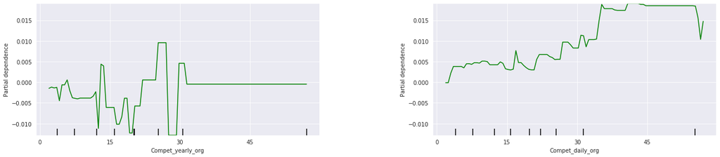

```python
from sklearn.ensemble.partial_dependence import partial_dependence, plot_partial_dependence

import seaborn as sns

sns.mpl.rcParams['figure.figsize'] = (20.0, 6.0)

gradBoost_regr = GradientBoostingRegressor(random_state=0, n_estimators=100)
gradBoost_regr.fit(x[["Compet_yearly_org", "Compet_daily_org"]],y)
my_plots = plot_partial_dependence(gradBoost_regr,
                                   features=range(0, 2), # column numbers of plots we want to show
                                   X=x[["Compet_yearly_org", "Compet_daily_org"]],            # raw predictors data.
                                   feature_names=["Compet_yearly_org", "Compet_daily_org"], # labels on graphs
                                   grid_resolution=100) # number of values to plot on x axis
```

#### Remarks

From the plot for daily competition we notice that the probability of a delay increases as the competition increases (percent of flight operated by that airline on that day and airport). This could be explained by two Hypotheses:

- The airline is unable to accomodate the high number of flights per day
- The airport is unable to accomodate the higher number of people showing up for flights

### 4. How important is the average 4 hour delay in predicting delays?

```
avg_del_4hour
```

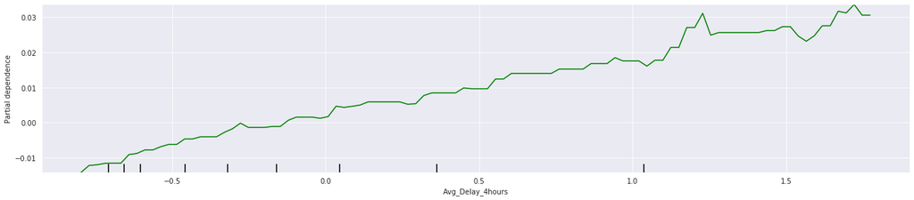

```python
print ("avg_del_4hour")
gradBoost_regr = GradientBoostingRegressor(random_state=0, n_estimators=100)
gradBoost_regr.fit(x[["Avg_Delay_4hours"]],y)
my_plots = plot_partial_dependence(gradBoost_regr,
                                   features=range(0, 1), # column numbers of plots we want to show
                                   X=x[["Avg_Delay_4hours"]],            # raw predictors data.
                                   feature_names=["Avg_Delay_4hours"], # labels on graphs
                                   grid_resolution=100) # number of values to plot on x axis
```

```python
selected_features_without_avg_del_4hours = ["alti","dwpfTrans","tmpf","Compet_daily", "TaxiOut","Origin_DEN",
                    "Origin_LGA", "Origin_RDU","DepTime_bins_Evening"]

print("------------selected_features_without_avg_del_4hours------------")
for m in models: (run_cross_validation(m, x[selected_features_without_avg_del_4hours], y, 10))

selected_features_without_avg_del_4hours = ["Compet_daily","TaxiOut","Origin_DEN","Origin_LGA", "Origin_RDU",
                     "DepTime_bins_Evening"]
print("\n------------selected_features_without_avg_del_4hours and without weather------------")
for m in models:
    (run_cross_validation(m, x[selected_features_without_avg_del_4hours], y, 10))

print("\n------------avg_del_4hours with weather------------")
for m in models:
    (run_cross_validation(m, x[selected_features_weather + ["Avg_Delay_4hours"]], y, 10))
```

```
------------selected_features_without_avg_del_4hours------------
--------------------------------------------------------------
 RandomForestRegressor: R2:  0.077074 |  RMSE:  0.050952
--------------------------------------------------------------
 GradientBoostingRegressor: R2:  0.14378 |  RMSE:  0.049077

------------selected_features_without_avg_del_4hours and without weather------------
--------------------------------------------------------------
 RandomForestRegressor: R2:  0.074782 |  RMSE:  0.051015
--------------------------------------------------------------
 GradientBoostingRegressor: R2:  0.11423 |  RMSE:  0.049916

------------avg_del_4hours with weather------------
--------------------------------------------------------------
 RandomForestRegressor: R2:  0.092642 |  RMSE:  0.050521
--------------------------------------------------------------
 GradientBoostingRegressor: R2:  0.10761 |  RMSE:  0.050103
```

#### Remarks

The partial dependence plot shows that there is indeed a strong positive dependency between this feature and the departure delay.

The average 4 hour delay proved to be a significant indicator as it significantly decreased the R-squared value by more than 5% when removed from the selected features set.

```python
display(dataset_original[dataset_original.UniqueCarrier == "MQ"].groupby(["Origin", "UniqueCarrier"])["Compet_daily"].mean())
```

```
Origin  UniqueCarrier
BOS     MQ                8.535869
DCA     MQ               11.969232
DFW     MQ               31.759251
LAX     MQ                7.536807
LGA     MQ               14.641151
ORD     MQ               25.016271
RDU     MQ               23.133156
SAN     MQ                8.048483
SJC     MQ               10.908021
Name: Compet_daily, dtype: float64
```

```python
dataset_original[dataset_original.UniqueCarrier == "MQ"].groupby(["Origin", "UniqueCarrier"])["Avg_Delay_4hours"].mean()
```

```
Origin  UniqueCarrier
BOS     MQ                6.279447
DCA     MQ                4.275220
DFW     MQ                9.539688
LAX     MQ                7.631385
LGA     MQ                8.545529
ORD     MQ               13.710104
RDU     MQ                7.242200
SAN     MQ                7.414322
SJC     MQ                5.602390
Name: Avg_Delay_4hours, dtype: float64
```

```python
display(dataset_original[dataset_original.UniqueCarrier == "F9"].groupby(["Origin", "UniqueCarrier"])["Compet_daily"].mean())
```

```
Origin  UniqueCarrier
DCA     F9                1.296439
DEN     F9               19.793570
DFW     F9                0.719900
LAX     F9                1.050750
LGA     F9                0.820112
SAN     F9                2.272827
SJC     F9                2.288267
Name: Compet_daily, dtype: float64
```

```python
dataset_original[dataset_original.UniqueCarrier == "F9"].groupby(["Origin", "UniqueCarrier"])["Avg_Delay_4hours"].mean()
```

```
Origin  UniqueCarrier
DCA     F9                4.035921
DEN     F9                8.193517
DFW     F9               10.860125
LAX     F9                7.445946
LGA     F9               15.719757
SAN     F9                7.649847
SJC     F9                4.327108
Name: Avg_Delay_4hours, dtype: float64
```

#### Remarks

The previous tables show the airports where our airlines have the most competition and those who have the highest average 4-hour delay